# Pipeline tools for reproducible data science

Ben Lambert

# Difficulties with applied data science

## Question

What are the key problems for you when doing data analysis in research?

## My problems

- Coding mistakes
- Changes to intermediate steps
- New data arrives
- Communicating to others
- Communicating to myself!

## Solutions?

- Coding mistakes: code defensively
- Changes to intermediate steps: have long R / bash scripts that can run things
- New data arrives: see above
- Communicating to others: write extensive comments and put these on the README
- Communicating to myself!: see above

## Problems with the solutions

- Coding mistakes: code defensively: will always make some mistakes
- Changes to intermediate steps: have long R / bash scripts that can run things: will potentially rerun EVERYTHING
- New data arrives: see above
- Communicating to others: write extensive comments and put these on the README: takes time over and above analysis
- Communicating to myself!: see above

# Pipeline tools

## What are pipeline tools?

- Pipeline tools are a way to write executable recipes for producing complex data analyses
- These recipes are humanly readable and useful for communication
- Their ultimate aim is to produce a directed acyclic graph (DAG) that shows how each output of an analysis is produced

## A DAG

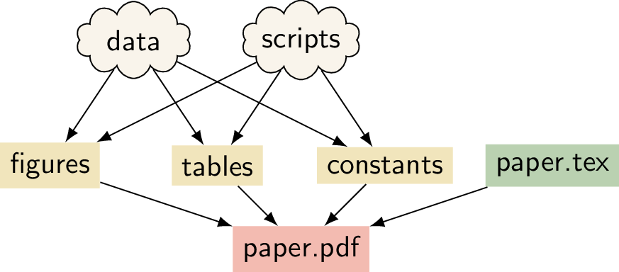

Taken from [“The Turing Way’’](https://the-turing-way.netlify.app/reproducible-research/make.html).

## What else do they offer?

- The tools track changes to files (code, data etc.)
- If a change is made to an intermediate segment of the code, when you type (something like) `make`, they only rerun downstream analyses

## Existing software

[figure not shown]

Its own language and been around a long time. It tracks changes to files based on time stamps. Can coordinate analyses across virtually any software: R, Python, Mathematica, C, bash and so on

## Existing software

[figure not shown]

Written in Python and favoured by bioinformaticians. It also tracks changes to files based on time stamps. Can coordinate analyses across virtually any software: R, Python, Mathematica, C, bash and so on

## Existing software

[figure not shown]

Written in R and only R specific. Clever way of tracking changes to files that can detect whether those changes will influence outputs. Produces really nice visualisations and is a great learning tool

# An example

## Disclaimer

Willfully taken and amended from the `targets` R package [website](https://books.ropensci.org/targets/walkthrough.html).

## Aim: develop a model for Ozone versus temperature

| Ozone | Solar.R | Wind | Temp | Month | Day |
| --- | --- | --- | --- | --- | --- |
| 41 | 190 | 7.4 | 67 | 5 | 1 |
| 36 | 118 | 8.0 | 72 | 5 | 2 |
| 12 | 149 | 12.6 | 74 | 5 | 3 |
| 18 | 313 | 11.5 | 62 | 5 | 4 |
| NA | NA | 14.3 | 56 | 5 | 5 |
| 28 | NA | 14.9 | 66 | 5 | 6 |
| 23 | 299 | 8.6 | 65 | 5 | 7 |
| 19 | 99 | 13.8 | 59 | 5 | 8 |
| 8 | 19 | 20.1 | 61 | 5 | 9 |
| NA | 194 | 8.6 | 69 | 5 | 10 |
| 7 | NA | 6.9 | 74 | 5 | 11 |
| 16 | 256 | 9.7 | 69 | 5 | 12 |
| 11 | 290 | 9.2 | 66 | 5 | 13 |
| 14 | 274 | 10.9 | 68 | 5 | 14 |
| 18 | 65 | 13.2 | 58 | 5 | 15 |
| 14 | 334 | 11.5 | 64 | 5 | 16 |
| 34 | 307 | 12.0 | 66 | 5 | 17 |
| 6 | 78 | 18.4 | 57 | 5 | 18 |
| 30 | 322 | 11.5 | 68 | 5 | 19 |
| 11 | 44 | 9.7 | 62 | 5 | 20 |

## Steps

- Get and clean data
- Fit a model: ozone ~ temperature
- Plot the model’s fit versus data
- Diagnose any issues with model fit; if necessary, change the model and rerun the above steps

## Demonstration

Go to separate repository!

# Conclusion

## Benefits of pipeline tools

- Improved communication to others and your future self
- Force you to write proper and clean code
- Huge efficiency gains, particularly later on in analyses (i.e. during the crunch period)

## Where to find out more

- [The Turing Way](https://the-turing-way.netlify.app/reproducible-research/make.html)
- [Targets R package website](https://books.ropensci.org/targets/)
- [OxRSE Snakemake tutorial](https://train.oxrse.uk/material/technology_and_tooling/snakemake)